# Peso do bebê

William Peixoto

knit mais recente: 28 de outubro 2018

# Análise do peso do bebê

Exercício de Métodos Inferenciais Avançados 2/18

### Peso do bebê

#### Modelo 3: Naïve

Da mesma forma que no modelo 1, vejamos com o que se parece um modelo com “tudo” dentro. Entretanto, como há campos com forte correlação entre si e com a variável dependente, precisamos nos livrar antes de:

- BirthWeightGm
- Low

```r
# ncb_weight_noNAs = complete.cases(ncb_weight)

fit_weight_1 = lm(BirthWeightOz ~ ., data=ncb_weight, na.action = na.omit)
summary(fit_weight_1)
```

```
##
## Call:
## lm(formula = BirthWeightOz ~ ., data = ncb_weight, na.action = na.omit)
##
## Residuals:
##     Min      1Q  Median      3Q     Max
## -60.563 -10.127  -0.529  10.196  51.910
##
## Coefficients: (3 not defined because of singularities)
##                             Estimate Std. Error t value Pr(>|t|)
## (Intercept)                -14.43123   17.93142  -0.805 0.421072
## PluralTwins                -24.91986    2.70144  -9.225  < 2e-16 ***
## PluralTriplets             -32.97512    8.37088  -3.939 8.58e-05 ***
## SexF                        -3.29510    0.87643  -3.760 0.000177 ***
## MomAge                       0.38218    0.08221   4.649 3.66e-06 ***
## Weeks                        3.46213    0.24021  14.413  < 2e-16 ***
## MaritalNot Married          -1.86531    1.13921  -1.637 0.101778
## RaceMomBlack                -3.75198    1.18866  -3.156 0.001631 **
## RaceMomAmericanIndian       -1.60304    3.60028  -0.445 0.656206
## RaceMomChinese               1.76533   11.61675   0.152 0.879237
## RaceMomHispanic            -13.40731   10.10354  -1.327 0.184730
## RaceMomFilipino            -31.44106   16.41419  -1.915 0.055637 .
## RaceMomOtherAsianOrPacific  -3.13136    3.55131  -0.882 0.378066
## HispMomM                    -1.33484   11.68819  -0.114 0.909093
## HispMomN                   -15.70756   15.35762  -1.023 0.306587
## HispMomO                    -0.03524   14.96804  -0.002 0.998122
## HispMomP                   -15.62046   13.03706  -1.198 0.231060
## HispMomS                    -3.63922   12.09842  -0.301 0.763611
## Gained                       0.28028    0.03222   8.700  < 2e-16 ***
## SmokeY                      -7.03396    1.29323  -5.439 6.32e-08 ***
## PremieY                     -7.51692    1.88396  -3.990 6.95e-05 ***
## MomRacehispanic                   NA         NA      NA       NA
## MomRaceother                      NA         NA      NA       NA
## MomRacewhite                      NA         NA      NA       NA
## ---
## Signif. codes:  0 '***' 0.001 '**' 0.01 '*' 0.05 '.' 0.1 ' ' 1
##
## Residual standard error: 16.38 on 1388 degrees of freedom
##   (41 observations deleted due to missingness)
## Multiple R-squared:  0.4595, Adjusted R-squared:  0.4517
## F-statistic:    59 on 20 and 1388 DF,  p-value: < 2.2e-16
```

Chama a atenção o coeficiente para `RaceMomFilipino`, com valor absoluto elevado e com significância de 0.055637, perto do limite escolhido para $\alpha$. Existe exatamente 1 registro de mãe com essa etnia.

```r
ncb_weight_NF = ncb_weight[ncb_weight$RaceMom != "Filipino",]
fit_weight_1b = lm(BirthWeightOz ~ ., data=ncb_weight_NF, na.action = na.omit)
summary(fit_weight_1b)
```

```
##
## Call:
## lm(formula = BirthWeightOz ~ ., data = ncb_weight_NF, na.action = na.omit)
##
## Residuals:
##     Min      1Q  Median      3Q     Max
## -60.563 -10.163  -0.534  10.200  51.910
##
## Coefficients: (3 not defined because of singularities)
##                             Estimate Std. Error t value Pr(>|t|)
## (Intercept)                -14.43123   17.93142  -0.805 0.421072
## PluralTwins                -24.91986    2.70144  -9.225  < 2e-16 ***
## PluralTriplets             -32.97512    8.37088  -3.939 8.58e-05 ***
## SexF                        -3.29510    0.87643  -3.760 0.000177 ***
## MomAge                       0.38218    0.08221   4.649 3.66e-06 ***
## Weeks                        3.46213    0.24021  14.413  < 2e-16 ***
## MaritalNot Married          -1.86531    1.13921  -1.637 0.101778
## RaceMomBlack                -3.75198    1.18866  -3.156 0.001631 **
## RaceMomAmericanIndian       -1.60304    3.60028  -0.445 0.656206
## RaceMomChinese               1.76533   11.61675   0.152 0.879237
## RaceMomHispanic            -13.40731   10.10354  -1.327 0.184730
## RaceMomOtherAsianOrPacific  -3.13136    3.55131  -0.882 0.378066
## HispMomM                    -1.33484   11.68819  -0.114 0.909093
## HispMomN                   -15.70756   15.35762  -1.023 0.306587
## HispMomO                    -0.03524   14.96804  -0.002 0.998122
## HispMomP                   -15.62046   13.03706  -1.198 0.231060
## HispMomS                    -3.63922   12.09842  -0.301 0.763611
## Gained                       0.28028    0.03222   8.700  < 2e-16 ***
## SmokeY                      -7.03396    1.29323  -5.439 6.32e-08 ***
## PremieY                     -7.51692    1.88396  -3.990 6.95e-05 ***
## MomRacehispanic                   NA         NA      NA       NA
## MomRaceother                      NA         NA      NA       NA
## MomRacewhite                      NA         NA      NA       NA
## ---
## Signif. codes:  0 '***' 0.001 '**' 0.01 '*' 0.05 '.' 0.1 ' ' 1
##
## Residual standard error: 16.38 on 1388 degrees of freedom
##   (41 observations deleted due to missingness)
## Multiple R-squared:  0.4592, Adjusted R-squared:  0.4518
## F-statistic: 62.03 on 19 and 1388 DF,  p-value: < 2.2e-16
```

#### Modelo 4: Menos é mais de novo

Baseado no contexto e nos valores observados das significâncias dos coeficientes do modelo 3, seleciono um conjunto menor de colunas para comparar…

```r
#COLSET_01 = c("Plural", "Sex",    "MomAge", "Weeks",
#              "Gained", "Smoke",
#              "BirthWeightOz")

fit_weight_2 = lm(BirthWeightOz ~ Plural + Sex + MomAge + Weeks + Gained + Smoke,
                  data = ncb_weight)
summary(fit_weight_2)
```

```
##
## Call:
## lm(formula = BirthWeightOz ~ Plural + Sex + MomAge + Weeks +
##     Gained + Smoke, data = ncb_weight)
##
## Residuals:
##     Min      1Q  Median      3Q     Max
## -63.672 -10.236  -0.157  10.486  49.522
##
## Coefficients:
##                 Estimate Std. Error t value Pr(>|t|)
## (Intercept)    -63.14127    7.06144  -8.942  < 2e-16 ***
## PluralTwins    -25.54412    2.71720  -9.401  < 2e-16 ***
## PluralTriplets -33.92719    8.45212  -4.014 6.28e-05 ***
## SexF            -3.42455    0.88540  -3.868 0.000115 ***
## MomAge           0.50662    0.07338   6.904 7.65e-12 ***
## Weeks            4.16276    0.17797  23.390  < 2e-16 ***
## Gained           0.28536    0.03215   8.875  < 2e-16 ***
## SmokeY          -7.24103    1.26076  -5.743 1.14e-08 ***
## ---
## Signif. codes:  0 '***' 0.001 '**' 0.01 '*' 0.05 '.' 0.1 ' ' 1
##
## Residual standard error: 16.59 on 1401 degrees of freedom
##   (41 observations deleted due to missingness)
## Multiple R-squared:  0.4408, Adjusted R-squared:  0.438
## F-statistic: 157.8 on 7 and 1401 DF,  p-value: < 2.2e-16
```

```r
fit_weight_2b = lm(BirthWeightOz ~ Plural + Sex + MomAge + Weeks + Gained + Smoke,
                  data = ncb_weight_NF)
summary(fit_weight_2b)
```

```
##
## Call:
## lm(formula = BirthWeightOz ~ Plural + Sex + MomAge + Weeks +
##     Gained + Smoke, data = ncb_weight_NF)
##
## Residuals:
##     Min      1Q  Median      3Q     Max
## -63.654 -10.185  -0.172  10.478  49.537
##
## Coefficients:
##                 Estimate Std. Error t value Pr(>|t|)
## (Intercept)    -63.40360    7.05644  -8.985  < 2e-16 ***
## PluralTwins    -25.56954    2.71478  -9.419  < 2e-16 ***
## PluralTriplets -33.98035    8.44453  -4.024 6.03e-05 ***
## SexF            -3.38139    0.88489  -3.821 0.000139 ***
## MomAge           0.51259    0.07339   6.985 4.39e-12 ***
## Weeks            4.16531    0.17782  23.425  < 2e-16 ***
## Gained           0.28563    0.03213   8.891  < 2e-16 ***
## SmokeY          -7.25583    1.25964  -5.760 1.03e-08 ***
## ---
## Signif. codes:  0 '***' 0.001 '**' 0.01 '*' 0.05 '.' 0.1 ' ' 1
##
## Residual standard error: 16.57 on 1400 degrees of freedom
##   (41 observations deleted due to missingness)
## Multiple R-squared:  0.4419, Adjusted R-squared:  0.4391
## F-statistic: 158.3 on 7 and 1400 DF,  p-value: < 2.2e-16
```

```r
anova(fit_weight_1, fit_weight_2)
```

```
## Analysis of Variance Table
##
## Model 1: BirthWeightOz ~ Plural + Sex + MomAge + Weeks + Marital + RaceMom +
##     HispMom + Gained + Smoke + Premie + MomRace
## Model 2: BirthWeightOz ~ Plural + Sex + MomAge + Weeks + Gained + Smoke
##   Res.Df    RSS  Df Sum of Sq      F    Pr(>F)
## 1   1388 372540
## 2   1401 385454 -13    -12914 3.7011 7.997e-06 ***
## ---
## Signif. codes:  0 '***' 0.001 '**' 0.01 '*' 0.05 '.' 0.1 ' ' 1
```

```r
anova(fit_weight_1b, fit_weight_2b)
```

```
## Analysis of Variance Table
##
## Model 1: BirthWeightOz ~ Plural + Sex + MomAge + Weeks + Marital + RaceMom +
##     HispMom + Gained + Smoke + Premie + MomRace
## Model 2: BirthWeightOz ~ Plural + Sex + MomAge + Weeks + Gained + Smoke
##   Res.Df    RSS  Df Sum of Sq     F    Pr(>F)
## 1   1388 372540
## 2   1400 384483 -12    -11943 3.708 1.554e-05 ***
## ---
## Signif. codes:  0 '***' 0.001 '**' 0.01 '*' 0.05 '.' 0.1 ' ' 1
```

## Verificação de premissas do modelo linear

c. Verifique as premissas do modelo linear.

- Resíduos
- Independência: os erros são independentes entre si
- Normalidade:
- Homocedasticidade (variância constante)
- Linearidade

### Peso do bebê Modelo 3: Naïve

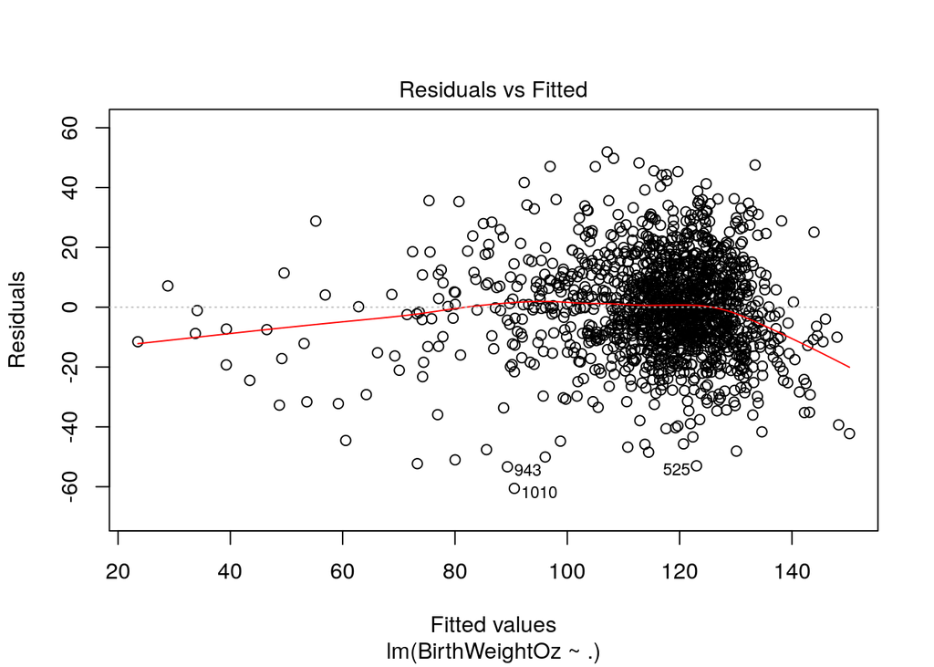

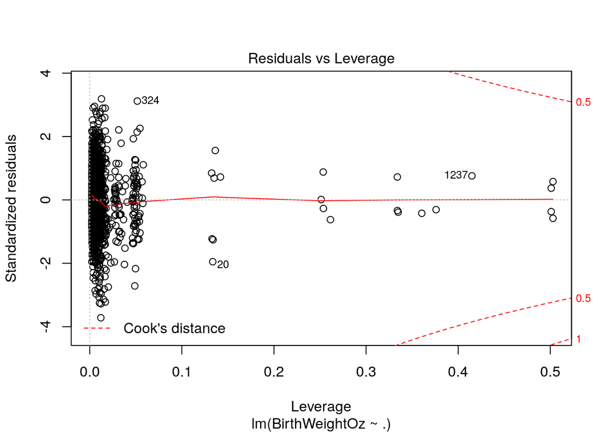

```r
plot(fit_weight_1)
```

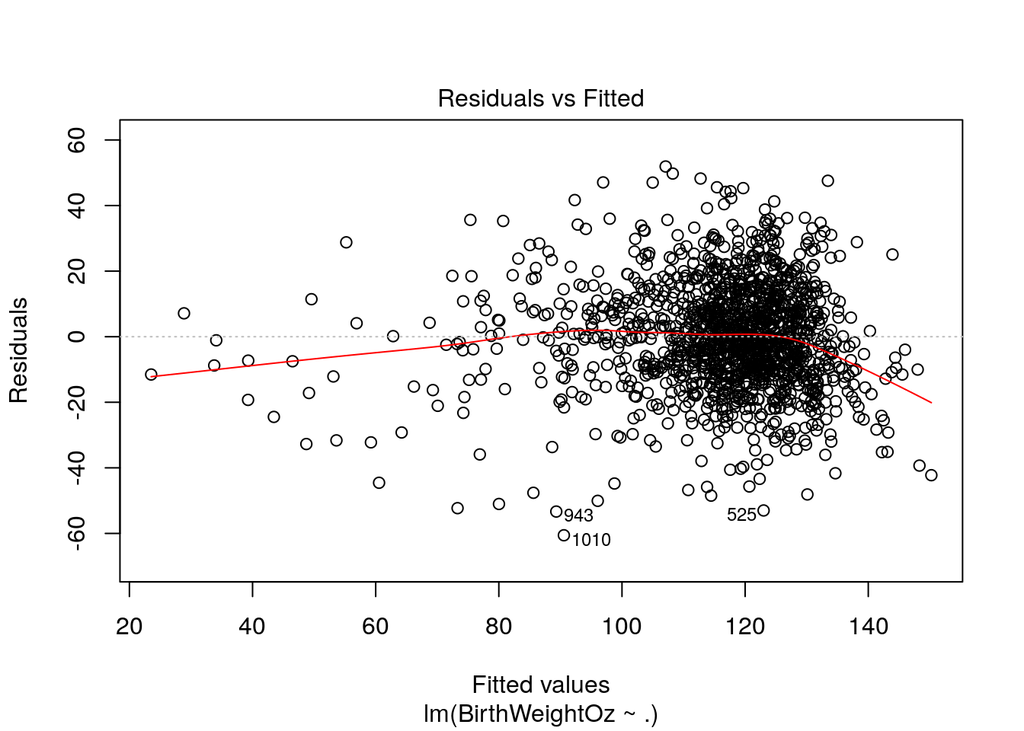

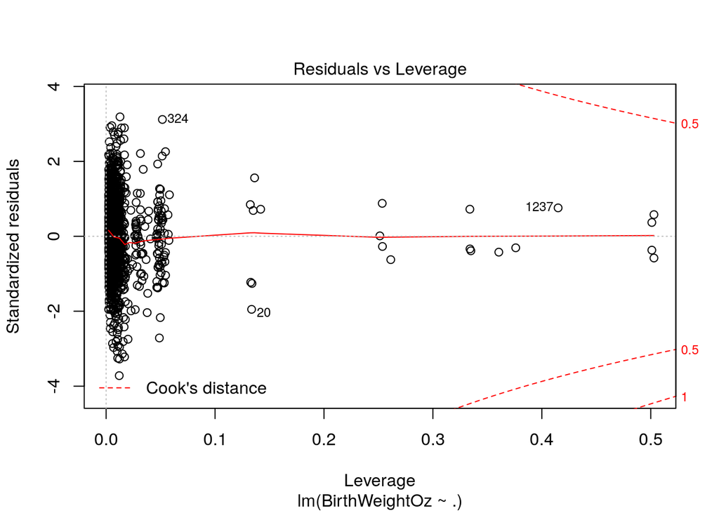

```r
plot(fit_weight_1b)
```